# Homework 3

Emma Podlich

2/10/2022

#### Due: 2/17/2022 before 11:59pm. Submit in Canvas (file upload).

## Instructions

1. Finish the in-class practice in Slides 3-12 in “Lecture 2-2-Practice for git”, link: https://yumouqiu.github.io/DS202-Spring2023/Practice/practice01.html
   1. Download the RMarkdown file with these homework instructions to use as a template for your work. Make sure to replace “Your Name” with your name.
   2. In the RMarkdown file, write down table of team members, and their github repository links;  
      the number of successful pull requests you made, and the github repository to which you requested a changes the number of pull requests you accepted, and the github repository from which you accepted.
   3. Write down a list with at least 3 tips of how to make working with git/github easier
2. Generate the graph of LifExp vs. gdpPercap for US, Canada (fixed data) and Australia by RMarkdown based on the data set “gapminder-5060”, like what we did in the class.  
   Please use Github to collaborate on this problem. For example, one member can create the plot of US in his/her repository. The other member will fork this repository, add the result for the second country, and make a pull request for merging into the main repository. Each member should at least analyze one country and make at least one pull request. **Please submit the RMarkdown file, the output file, and the screen shot of the successful pull request and the merge.**
3. Write a paragraph (~200 words) describing an example of what you consider data science. Write your paragraph in R Markdown. Include at least
   1. one link to a chart or an image and
   2. at least one itemized or enumerated list.

Note: your submission is supposed to be fully reproducible, i.e. the TA and I will ‘knit’ your submission in RStudio. Including the link to the image is the tricky part here. Make sure that you don’t use any file structure that depends on your computing environment.

For the submission: submit your solution in an **R Markdown file** and (just for insurance) submit the corresponding html (or Word) file with it.

# Question 1

Team Members: Emma (https://github.com/epodlich/practice1-epodlich) & Ryan (https://github.com/ryancorydon8/practice1-ryancorydon8)

Number of successful pull requests I made: 3 (on Ryan’s repository: link above)

Number of pull requests I accepted: 5 (from Ryan’s repository: link above)

### Tips to Making Git/GitHub Easier

1. The main tip for working through Git/GitHub would be to practice going through the steps of making pull requests and accepting them. Practice being repetition will make it easier over time. During class, we made multiple pull requests and this process got easier with each lecture that we did it in.
2. Another thing that I did to make the process easier was to write down a list of the steps, stating what button to place in each step. Creating a list of the steps helped me think through what I should be doing so that I could remember the steps without the list easier.
3. Also, I would recommend that beginners start with using just the github website with doing pull requests / accepts because it is easier to start with just the website so that it isn’t too overwhelming. Then, once you are comfortable with doing pull requests and acceptances, you can start trying to connect to github on RStudio. This way, the process isn’t so overwhelming.

# Question 2

### Canada Plot (Unfixed Data) - Emma

```r
library(ggplot2)
life5060 <- read.csv("https://raw.githubusercontent.com/epodlich/practice1-epodlich/main/gapminder-5060.csv")
View(life5060)
dim(life5060)
```

```
## [1] 568   6
```

```r
canada <- life5060[life5060$country == "Canada", ]
head(canada)
```

```
##    country continent year   lifeExp      pop gdpPercap
## 81  Canada  Americas 1952     68.75 14785584  11367.16
## 82  Canada  Americas 1957 999999.00 17010154  12489.95
## 83  Canada  Americas 1962     71.30 18985849  13462.49
## 84  Canada  Americas 1967     72.13 20819767  16076.59
```

```r
dim(canada)
```

```
## [1] 4 6
```

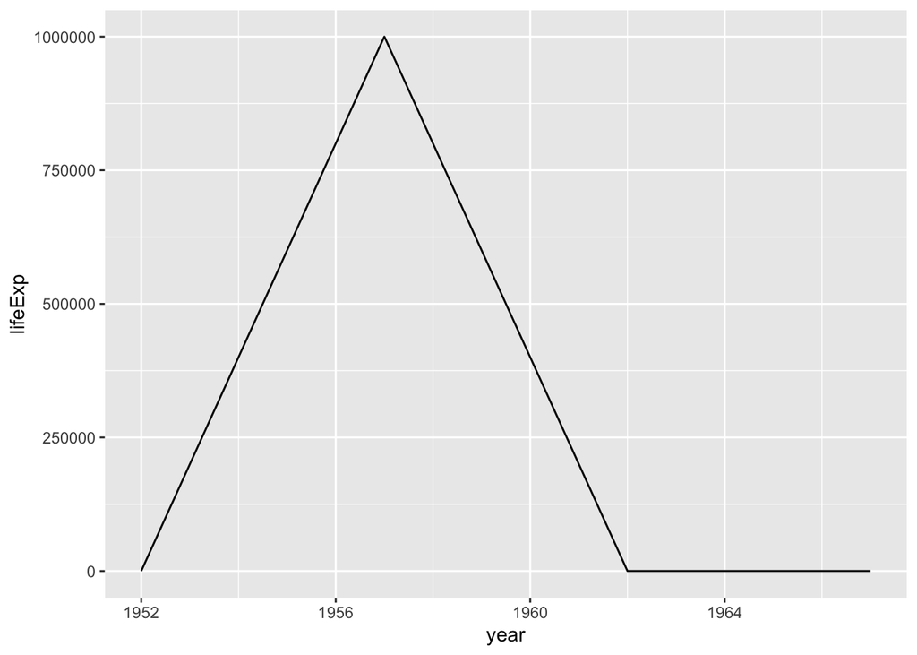

```r
ggplot(data = canada, aes(x = year, y = lifeExp)) + geom_line()
```

### Canada Plot (Fixed Data) - Emma

```r
canada_fixed = canada
canada_fixed$lifeExp[canada_fixed$year==1957] = 69.96
canada_fixed
```

```
##    country continent year lifeExp      pop gdpPercap
## 81  Canada  Americas 1952   68.75 14785584  11367.16
## 82  Canada  Americas 1957   69.96 17010154  12489.95
## 83  Canada  Americas 1962   71.30 18985849  13462.49
## 84  Canada  Americas 1967   72.13 20819767  16076.59
```

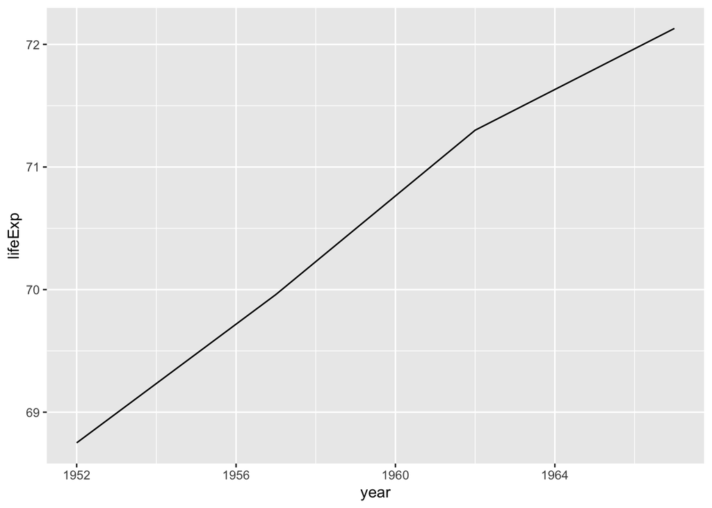

```r
ggplot(data = canada_fixed, aes(x = year, y = lifeExp)) + geom_line()
```

### Add the United States - Ryan

```r
library(ggplot2)
life5060 <- read.csv("https://raw.githubusercontent.com/epodlich/practice1-epodlich/main/gapminder-5060.csv")
View(life5060)
dim(life5060)
```

```
## [1] 568   6
```

```r
us <- life5060[life5060$country == "United States", ]
head(us)
```

```
##           country continent year lifeExp       pop gdpPercap
## 537 United States  Americas 1952   68.44 157553000  13990.48
## 538 United States  Americas 1957   69.49 171984000  14847.13
## 539 United States  Americas 1962   70.21 186538000  16173.15
## 540 United States  Americas 1967   70.76 198712000  19530.37
```

```r
dim(us)
```

```
## [1] 4 6
```

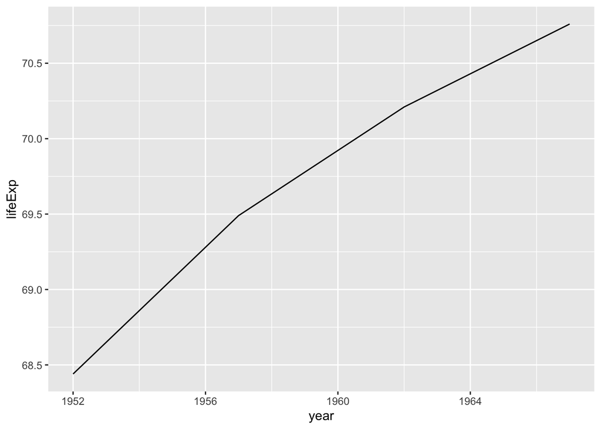

```r
ggplot(data = us, aes(x = year, y = lifeExp)) + geom_line()
```

```r
us_fixed = us
us_fixed$lifeExp[us_fixed$year==1957] = 69.49
us_fixed
```

```
##           country continent year lifeExp       pop gdpPercap
## 537 United States  Americas 1952   68.44 157553000  13990.48
## 538 United States  Americas 1957   69.49 171984000  14847.13
## 539 United States  Americas 1962   70.21 186538000  16173.15
## 540 United States  Americas 1967   70.76 198712000  19530.37
```

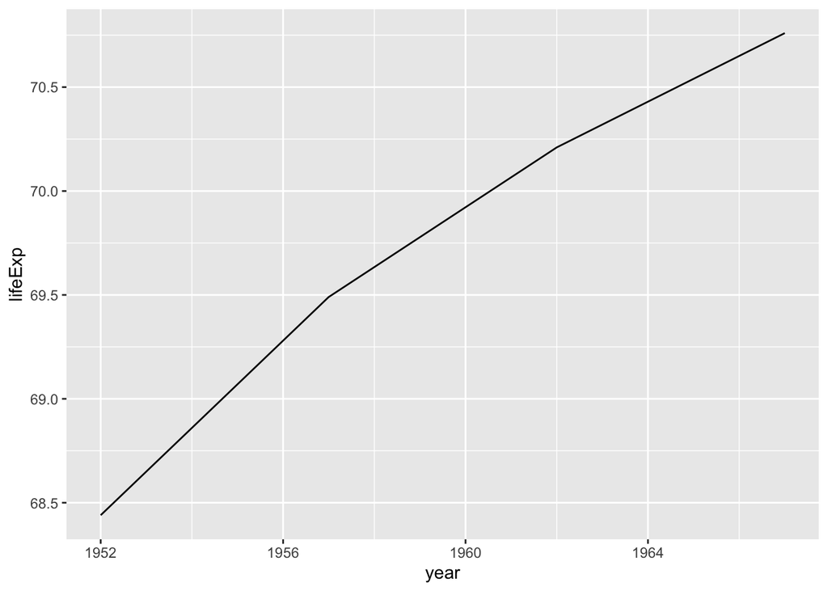

```r
ggplot(data = us_fixed, aes(x = year, y = lifeExp)) + geom_line()
```

### Add Australia - Emma

```r
australia <- life5060[life5060$country == "Australia", ]
head(australia)
```

```
##      country continent year lifeExp      pop gdpPercap
## 21 Australia   Oceania 1952   69.12  8691212  10039.60
## 22 Australia   Oceania 1957   70.33  9712569  10949.65
## 23 Australia   Oceania 1962   70.93 10794968  12217.23
## 24 Australia   Oceania 1967   71.10 11872264  14526.12
```

```r
dim(australia)
```

```
## [1] 4 6
```

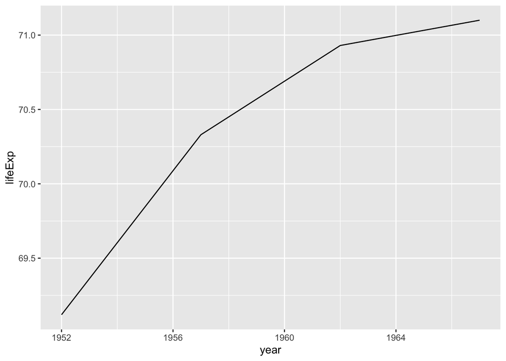

```r
ggplot(data = australia, aes(x = year, y = lifeExp)) + geom_line()
```

### Add All Three Together - Emma

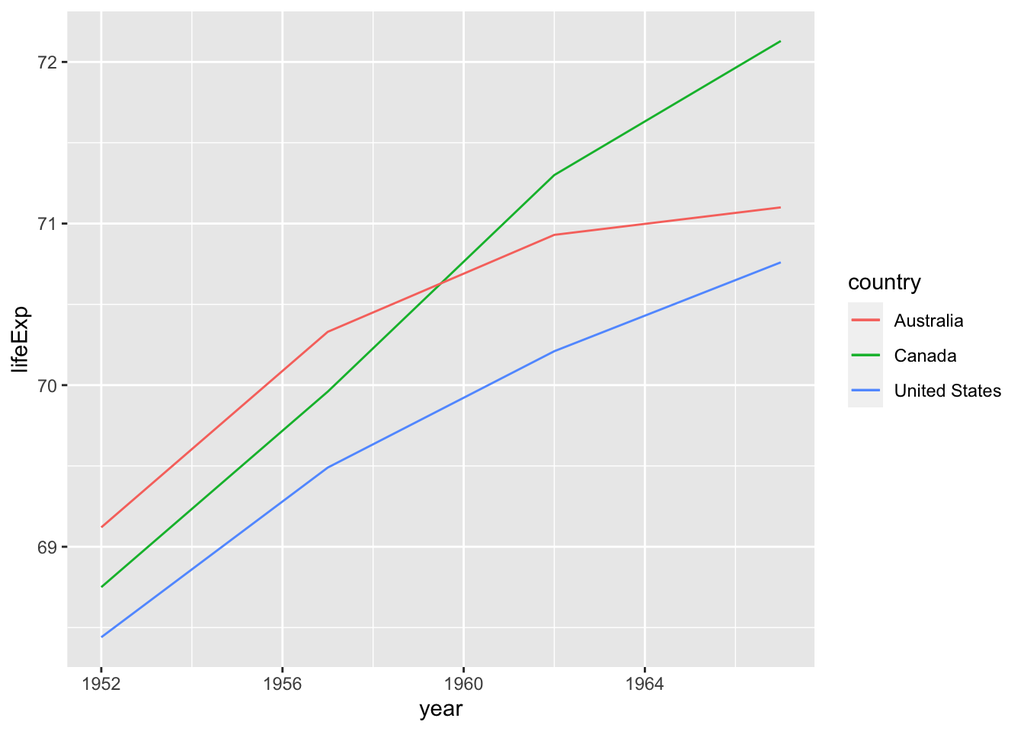

```r
ggplot(data = canada_fixed, aes(x = year, y = lifeExp, colour=country)) + geom_line() + geom_line(data = life5060[life5060$country == "United States", ]) + geom_line(data = life5060[life5060$country == "Australia", ])
```

# Question 3

To me, data science is the process of getting data from a source and then analyzing that data so that the information is useful to someone or something. For instance, a data scientist could get a bunch of medical data of someone’s blood pressure and personal information (age, eating habits, lifestyle habits etc.) to predict when/if they will get hypertension, or high blood pressure, in the future. However, there are quite a few steps in the process of data science in order to make the data science work useful to a company or person. Some of the steps are listed below:

1. Getting the Data
- Collecting blood pressure data
- Surveying personal information
2. Processing the Data
- Inputting the data into an analysis software
- Data cleaning
3. Analyzing the Data
- Predictive Analysis
- Assess Performance
4. Communicating the Results
- Telling patients if they are likely to get hypertension
- Presenting to diagnostic companies

Link to Performance Plot: https://www.ncbi.nlm.nih.gov/pmc/articles/PMC7567367/figure/pone.0240370.g002/